# STAT380_Mini-Project2

Sammit Bal, Thaddeus Poff, Jason Zhang

2025-04-01

## Front Matter

```r
remove(list = ls())
library(tidyverse)
library(FNN)
library(readxl)
COD_dataset <- read_excel("./CODGames2_mp.xlsx")
```

**Contributions:**

- *Sammit:* Question 1, 2 variables of Question 2
- *Thaddeus:* 1 variable of Question 2, Question 4
- *Jason:* 2 variables of Question 2, Question 3 (+ edited Question 4) >:)

## Task 1

**Question:** Explain why you should avoid using the function `na.omit()` to remove observations (rows) with missing data for the `CODGames2_mp` dataset.

We should avoid using the `na.omit()` function because it will remove an unnecessary amount of observations which still have valuable data in them. In this data set we have a lot of unused variables because of the types of game modes that are played in COD. Certain game modes keep track of more data than others. For example, “Kill Confirmed” keeps track of “Confirms”, “Denies”, and “Objectives.”

These are variables that are otherwise unused when not playing “Kill Confirmed”. Overall, na.omit is the wrong function to use because it does not consider the possibility that we don’t need every column. We should instead use a function that removes observations on a column by column basis.

```r
countNA <- function(dat){
  numNA <- sum(is.na(dat))
  return(numNA)
}

apply(X = COD_dataset, MARGIN = 2, FUN = countNA)
```

```
##           Map1           Map2         Choice        MapVote           Date
##             43             43              1             43              0
##    FullPartial         Result   Eliminations         Deaths          Score
##              0              0              0              0              0
##         Damage        TotalXP  PrimaryWeapon         XPType  DidPlayerVote
##              0              0              0              0              0
##       GameType       Confirms         Denies     Objectives ObjectiveKills
##              0            208            208            205            200
##       Captures       Diffuses         Plants      Detonates       Deposits
##            208            211            211            211            211
##       Time_Sec       Time_Min
##            203            203
```

## Task 2

### Overview

Explore 5 more variables of your choice.

- You should explore at least one categorical and at least one quantitative variable.
- Perform a univariate exploration of each variable. (In other words, do not look at the relationship between pairs of variables. Instead, just explore each variable by itself.)

*For each variable, you should…*

1. Identify the variable, the type of variable (categorical, quantitative, etc.), information about the types of values the variable can take, and the amount of missing data within the variable.
2. Report some summary statistics and make a visualization.
3. *If a variable is categorical…*
   1. Make a table of possible values and include counts or proportions.
   2. Then, make an appropriate plot to show the distribution of values.
4. *If a variable is quantitative…*
   1. Include some basic summary stats like the mean, median, standard deviation, min, max, etc.
   2. Make an appropriate plot to show the distribution of values.
5. For each variable, write a few sentences to describe what you have learned about the variable. Incorporate the summary statistics and comment on the amount of missingness into your discussion. Remember, the goal is not to make the plot/calculate the summaries. The goal is to use plots and summaries to gain knowledge from the data.
6. Place each discussion next to the relevant plot/summary statistics rather than writing code for all 5 variables first followed by all discussion. If you the discussions are not near the plots, it makes it difficult for your audience to follow your explanations without excessive scrolling

### Deaths (Variable 1)

We were curious about the quantitative variable “Deaths”, which seems to refer to the aggregate number of deaths in a game. Before studying the distribution of the variable, let’s first check the number of NA values:

```r
# Filter: Find the number of NA values in Deaths
COD_dataset %>%
  filter(is.na(Deaths)) %>%
  summarize(Number_of_NA = n())
```

```
## # A tibble: 1 × 1
##   Number_of_NA
##          <int>
## 1            0
```

…And the statistics collected from the games recorded contained no NA values for Deaths.

**Summary Statistics:**

```r
# Summary statistics for Deaths variable
COD_dataset %>%
  select(Deaths) %>%
  summarize(min = min(Deaths),
    max = max(Deaths),
    mean = mean(Deaths),
    median = median(Deaths),
    sd = sd(Deaths))
```

```
## # A tibble: 1 × 5
##     min   max  mean median    sd
##   <dbl> <dbl> <dbl>  <dbl> <dbl>
## 1     4    42  15.0     15  5.13
```

**Visualization:**

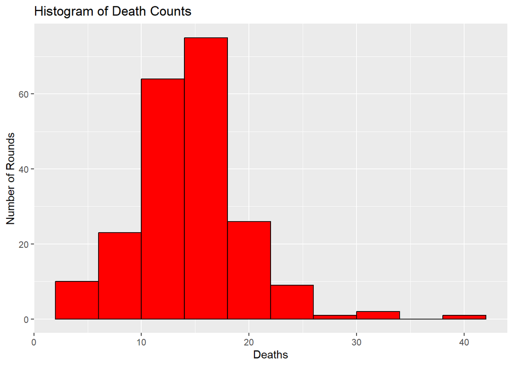

```r
# Histogram of the variable "Death"'s values to show distribution
ggplot(data = COD_dataset,
  mapping = aes(x = Deaths)) +
  geom_histogram(binwidth = 4, fill = "red", color = "black") +
  labs(y = "Number of Rounds",
  title = "Histogram of Death Counts")
```

**Analysis:**

Let’s analyze the distribution: based on “Histogram of Death Counts”, we can see a concentration of data roughly at the midpoint between 10 and 20 deaths. This is affirmed by the mean and median values reported by the summary statistic table, which is exactly 15.0 and 15 deaths respectively.

Overall, this distribution is reminiscent of a unimodal, normal distribution with just a slight rightwards skew with a small fraction ($\sim 5$) rounds exceeding 25 Deaths.

### XPType (Variable 2)

For the second variable, we considered the categorical variable “XPType”, which seems to refer to some sort of “bonus” in COD where players would presumably receive a multiplicative/additive/otherwise bonus to their XP gains.

Based on the dataset, there are 2 different types of XPType:

```r
# Table of types of XPType
COD_dataset %>%
  select(XPType) %>%
  distinct()
```

```
## # A tibble: 2 × 1
##   XPType
##   <chr>
## 1 10% Boost
## 2 Double XP + 10%
```

The statistics collected from the rounds recorded contained no NA values for XPType:

```r
# Filter: Find the number of NA values in XPType
COD_dataset %>%
  filter(is.na(XPType)) %>%
  summarize(Number_of_NA = n())
```

```
## # A tibble: 1 × 1
##   Number_of_NA
##          <int>
## 1            0
```

**Visualization:**

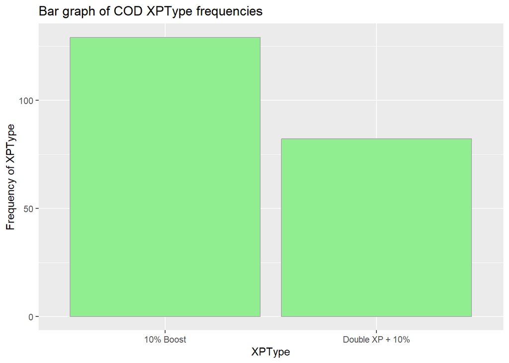

```r
# Aggregate of XPType counts per unique XPType
COD_PW_df <- COD_dataset %>%
  select(XPType) %>%
  group_by(XPType) %>%
  summarize(N = n())

# Bar graph visualization of XPType counts
ggplot(data = COD_PW_df,
       mapping = aes(x = XPType, y = N)) +
  geom_bar(stat = "identity", fill = "lightgreen",
           linewidth = 0.5, colour = "darkgray") +
  labs(y = "Frequency of XPType",
       title = "Bar graph of COD XPType frequencies")
```

```r
# Table of XPType frequencies
COD_dataset %>%
  select(XPType) %>%
  group_by(XPType) %>%
  summarize(Count = n(),
            Percent_of_Total = paste0(round(n()/nrow(COD_dataset)*100,2), "%"))
```

```
## # A tibble: 2 × 3
##   XPType          Count Percent_of_Total
##   <chr>           <int> <chr>
## 1 10% Boost         129 61.14%
## 2 Double XP + 10%    82 38.86%
```

**Analysis:**

There notably isn’t enough variety in the sorts of XP bonuses (XPType) to argue any sort of distribution (except, perhaps, Bernoulli).

Why the relative frequencies are not more even or skewed towards `Double XP + 10%`, in spite of this bonus seeming mathematically better with respect to XP gain, is perhaps due to relative availability— the bonus might not be available for the majority of times when players can actually play.

### FullPartial (Variable 3)

We are interested in the categorical variable `FullPartial` which describes if the player played a full game, or only a partial game.

The statistics collected from the rounds recorded contained no NA values for FullPartial:

```r
# Filter: Find the number of NA values in FullPartial
COD_dataset %>%
  filter(is.na(FullPartial)) %>%
  summarize(Number_of_NA = n())
```

```
## # A tibble: 1 × 1
##   Number_of_NA
##          <int>
## 1            0
```

**Visualization:**

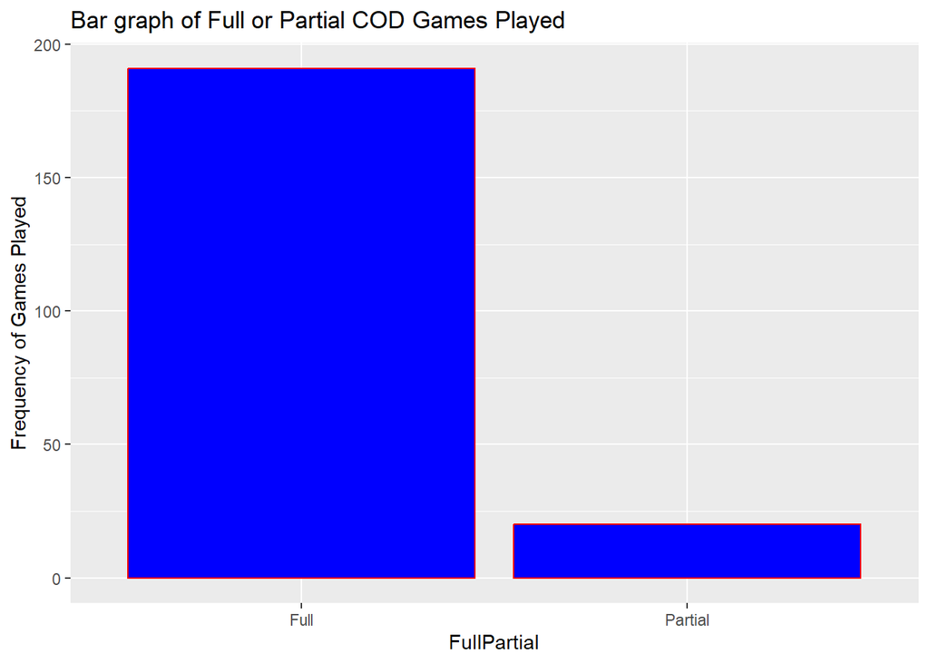

```r
Cod_FP <-
  COD_dataset %>%
  select(FullPartial) %>%
  group_by(FullPartial) %>%
  summarize(count = n())


ggplot(data = Cod_FP,
       mapping = aes(x = FullPartial, y = count)) +
  geom_bar(stat = "identity", fill = "blue",
           linewidth = 0.5, colour = "red") +
  labs(y = "Frequency of Games Played",
       title = "Bar graph of Full or Partial COD Games Played")
```

```r
COD_dataset %>%
  select(FullPartial) %>%
  group_by(FullPartial) %>%
  summarize(Count = n(),
            Percent_of_Total = paste0(round(n()/nrow(COD_dataset)*100,2), "%"))
```

```
## # A tibble: 2 × 3
##   FullPartial Count Percent_of_Total
##   <chr>       <int> <chr>
## 1 Full          191 90.52%
## 2 Partial        20 9.48%
```

**Analysis:**

Most players that were surveyed in this dataset played full games. For the players that played partial games, we are still unsure at what point they joined the game (whether that be in the beginning, middle, or end of the game, the dataset doesn’t make a distinction). It’s worth noting that we might be able to make an inference, based on their eliminations/deaths/score from that game played, for what (average) percentage of the game partial-game players played though.

### Damage (Variable 4)

We were curious about the quantitative variable “Damage”, which refers to the total amount of damage dealt to opposing players with weapons. The statistics collected from the data set contained no NA values for Damage.

```r
# Filter: Find the number of NA values in Damage
COD_dataset %>%
  filter(is.na(Damage)) %>%
  summarize(Number_of_NA = n())
```

```
## # A tibble: 1 × 1
##   Number_of_NA
##          <int>
## 1            0
```

**Summary Statistics:**

```r
# Summary statistics for Damage variable
COD_dataset %>%
  select(Damage) %>%
  summarize(min = min(Damage),
    max = max(Damage),
    mean = mean(Damage),
    median = median(Damage),
    sd = sd(Damage),
    Q1 = quantile(Damage, 0.25),
    Q3 = quantile(Damage, 0.75))
```

```
## # A tibble: 1 × 7
##     min   max  mean median    sd    Q1    Q3
##   <dbl> <dbl> <dbl>  <dbl> <dbl> <dbl> <dbl>
## 1    56   960  415.    397  166.  304.   508
```

**Visualization:**

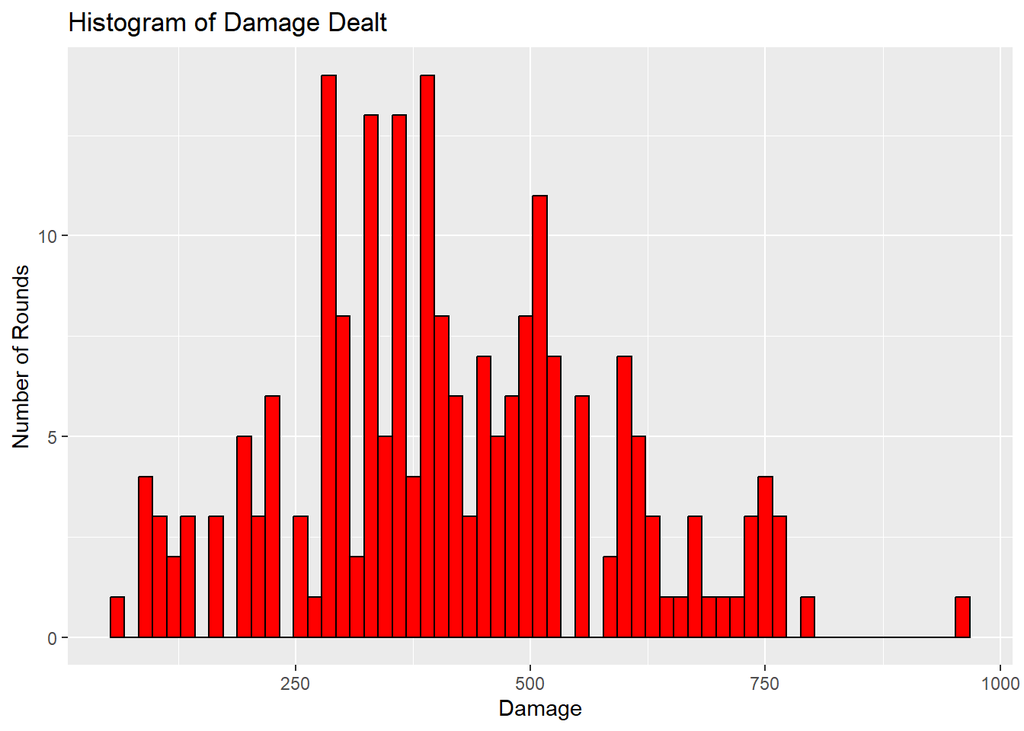

```r
# Histogram of the variable "Damage" values to show distribution
ggplot(data = COD_dataset,
  mapping = aes(x = Damage)) +
  geom_histogram(binwidth = 15, fill = "red", color = "black") +
  labs(y = "Number of Rounds",
  title = "Histogram of Damage Dealt")
```

**Analysis:**

Based on the above histogram, we can see a concentration of data between 250 and 550 damage. This is affirmed by the mean and median values reported by the summary statistic table, which is at 415 and 397 damage respectively. We also see an outlier value at 960. Overall, this distribution is unimodal, has a normal distribution with a slight right skew.

### GameType (Variable 5)

For the fifth variable, we explored the categorical variable “GameType”, which refers to the game mode or a new set of objectives the player is meant to accomplish. Game modes can add new more challenging aspects to the game. For example, in Hardpoint an objective is created and your team must control the point for a certain period of time in order to win or score points.

Based on the dataset, there are 4 different types of GameType’s:

```r
# Table of types of GameType
COD_dataset %>%
  select(GameType) %>%
  distinct()
```

```
## # A tibble: 4 × 1
##   GameType
##   <chr>
## 1 HC - TDM
## 2 HC - Kill Confirmed
## 3 HC - Hardpoint
## 4 HC - Domination
```

The statistics collected from the rounds recorded contained no NA values for XPType:

```r
#Find the number of NA values in GameType
COD_dataset %>%
  filter(is.na(GameType)) %>%
  summarize(Number_of_NA = n())
```

```
## # A tibble: 1 × 1
##   Number_of_NA
##          <int>
## 1            0
```

**Visualization:**

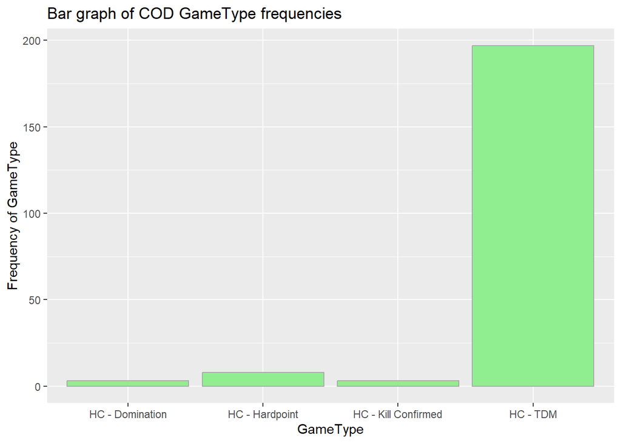

```r
# Aggregate of GameType counts per unique GameType
COD_PW_df <- COD_dataset %>%
  select(GameType) %>%
  group_by(GameType) %>%
  summarize(N = n())

# Bar graph visualization of GameType counts
ggplot(data = COD_PW_df,
       mapping = aes(x = GameType, y = N)) +
  geom_bar(stat = "identity", fill = "lightgreen",
           linewidth = 0.5, colour = "darkgray") +
  labs(y = "Frequency of GameType",
       title = "Bar graph of COD GameType frequencies")
```

```r
# Table of GameType frequencies
COD_dataset %>%
  select(GameType) %>%
  group_by(GameType) %>%
  summarize(Count = n(),
            Percent_of_Total = paste0(round(n()/nrow(COD_dataset)*100,2), "%"))
```

```
## # A tibble: 4 × 3
##   GameType            Count Percent_of_Total
##   <chr>               <int> <chr>
## 1 HC - Domination         3 1.42%
## 2 HC - Hardpoint          8 3.79%
## 3 HC - Kill Confirmed     3 1.42%
## 4 HC - TDM              197 93.36%
```

**Analysis:**

As we can see there isn’t much variety in GameType, this could be for a variety of reasons. One reason could be because it’s the default game mode recommended to players. Another explanation could be its simplicity, to win in this game mode you simply have to have more eliminations than the other team. For a game with a large casual player base, maybe picking these harder isn’t as fun or appealing which could explain why TDM is the most dominate GameType in our dataset.

Overall, we can assume that Hard Core - Team Death Match (TDM) is the most popular game mode with HC - Hardpoint after it and HC - Domination and HC - Kill Confirmed equal in popularity.

## Task 3

**Creating the binary variable `WinLoss`:**

```r
# WinLoss = 1 (Win), 0 (Loss)
COD_dataset <- COD_dataset %>%
  # Creating integers PlayerScore and OtherScore
  separate(Result,
           into = c("PlayerScore", "OtherScore"),
           sep = "-") %>%
  mutate(PlayerScore = as.integer(PlayerScore)) %>%
  mutate(OtherScore = as.integer(OtherScore)) %>%
  # Restoring "Result" variable
  mutate(Result = COD_dataset$Result) %>%
  mutate(WinLoss = ifelse(PlayerScore > OtherScore,
                      ifelse(PlayerScore == OtherScore,
                             "Draw", "Win"), "Loss"))
```

**Visualization:**

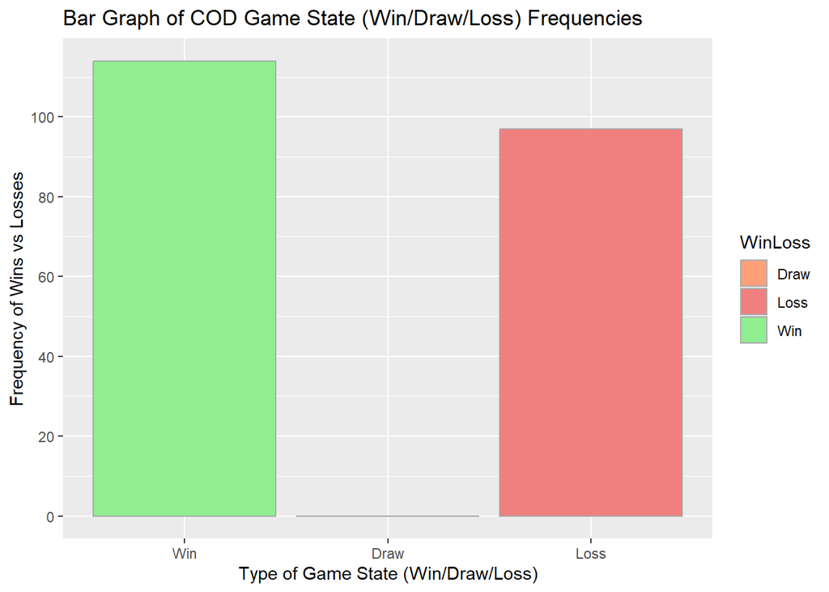

```r
# Aggregate of game state counts per unique game state
COD_WL_df <- COD_dataset %>%
  select(WinLoss) %>%
  group_by(WinLoss) %>%
  summarize(N = n())

# Adding a "Draw" row if it doesn't exist
if(nrow(COD_WL_df) == 2) {
  COD_WL_df <- rbind(COD_WL_df, c("Draw", 0)) %>%
    mutate(N = as.integer(N))
}

# Bar graph visualization of WinLoss counts
ggplot(data = COD_WL_df,
       mapping = aes(x = fct_relevel(WinLoss,
                         c("Win", "Draw", "Loss")),
                     y = N,
                     fill = WinLoss)) +
  geom_bar(stat = "identity",
           linewidth = 0.5,
           color = "darkgray") +
  scale_fill_manual(values = c("Win" = "lightgreen",
                               "Draw" = "lightsalmon",
                               "Loss" = "lightcoral")) +
  scale_y_continuous(breaks = seq(0, 120, by = 20)) +
  labs(x = "Type of Game State (Win/Draw/Loss)",
       y = "Frequency of Wins vs Losses",
       title = "Bar Graph of COD Game State (Win/Draw/Loss) Frequencies")
```

```r
# Table of XPType frequencies
COD_dataset %>%
  select(WinLoss) %>%
  group_by(WinLoss) %>%
  summarize(Count = n(),
            Percent_of_Total = paste0(round(n()/nrow(COD_dataset)*100,2), "%"))
```

```
## # A tibble: 2 × 3
##   WinLoss Count Percent_of_Total
##   <chr>   <int> <chr>
## 1 Loss       97 45.97%
## 2 Win       114 54.03%
```

## Task 4

**Our Group’s Question:** “Does the Score help predict the result of a round (win/loss), where a”loss” includes draws?”

*Explanation:* Assuming that a player’s score indicates their performance, we believe that a higher score would indicate a higher performance and therefore a greater likelihood that their team wins. This is complicated by conflicting factors such as the fact that score might naturally increase regardless of performance as game duration increases, though, so some data analysis is needed.

#### **Step 1: Calculate `logit`:**

```r
# Creating indicator variable "WinLossNum"
COD_dataset <-
  COD_dataset %>%
  mutate(WinLossNum = ifelse(WinLoss == "Win", 1, 0))

# Creating generalized linear regression model
modelglm <- glm(WinLossNum ~ Score, family = binomial, data = COD_dataset)
summary(modelglm)
```

```
##
## Call:
## glm(formula = WinLossNum ~ Score, family = binomial, data = COD_dataset)
##
## Coefficients:
##               Estimate Std. Error z value Pr(>|z|)
## (Intercept) -3.324e-01  3.159e-01  -1.052   0.2926
## Score        1.689e-04  9.776e-05   1.727   0.0841 .
## ---
## Signif. codes:  0 '***' 0.001 '**' 0.01 '*' 0.05 '.' 0.1 ' ' 1
##
## (Dispersion parameter for binomial family taken to be 1)
##
##     Null deviance: 291.14  on 210  degrees of freedom
## Residual deviance: 288.06  on 209  degrees of freedom
## AIC: 292.06
##
## Number of Fisher Scoring iterations: 4
```

- `Intercept` $= -0.3324$, `Score` $= 0.0001689$
- *Note:* In spite of the `Pr(>|z|)` of the Score and Intercept exceeding the $\alpha$ value of $0.05$, we still will use these figures, as an $\alpha$ value of $0.05$ is too low for predicting categorical variables. Specifically for slope, an $\alpha$ value of $0.15$ or greater would be appropriate, which this probability exceeds (is below).

*Calculation for `logit` form:*

$$\large{\log(\text{Odds}_{WinLoss}) =
-0.3324 + 0.0001689 \cdot \text{Score}}$$

#### **Step 2: Convert `logit` to `odds`:**

$$\large{
\begin{align}
\text{Odds}_{\text{WinLoss}} = e^{-0.3324 + 0.0001689 \cdot
\text{Score}}
\end{align}
}$$

- *Slope:* $\large{e^{0.0001689} \approx 1.00016891426 (+0.01689\%)}$
- *Interpretation of* *ODDS:* As a person’s Score increases by 1 point, we expect the odds of winning to change by a factor of 1.00016891426, meaning that their odds of winning increases by 0.01689%.

#### **Step 3: Converting `odds` to `probability`:**

$$\large{
\text{p}_{\text{WinLoss}} = \dfrac{e^{-0.3324 + 0.0001689 \cdot
\text{Score}}}{1 + e^{-0.3324 + 0.0001689 \cdot \text{Score}}}
}$$

#### **Step 4: Interpreting the Results and Answering the Question:**

```r
# prob_win: Applies the formula in Step 3 to summary stats of Score
intercept <- -0.3324
slope <- 0.0001689

prob_win <- function(Score) exp(intercept + slope * Score) /
                            (1 + exp(intercept + slope * Score))


# Viewing summary statistics of prob_win
COD_dataset %>%
  select(Score) %>%
  summarize(
    min = prob_win(min(Score)),
    max = prob_win(max(Score)),
    mean = prob_win(mean(Score)),
    median = prob_win(median(Score)),
    sd = prob_win(sd(Score)),
    Q1 = prob_win(quantile(Score, 0.25)),
    Q3 = prob_win(quantile(Score, 0.75)))
```

```
## # A tibble: 1 × 7
##     min   max  mean median    sd    Q1    Q3
##   <dbl> <dbl> <dbl>  <dbl> <dbl> <dbl> <dbl>
## 1 0.422 0.712 0.541  0.534 0.479 0.501 0.568
```

**Interpretation of the Probabilities:**

Based on the table above— which measures the distributions of winning by aggregating the probabilities of winning of each Score— we can see that the majority of these summary statistics, starting from the 1st quartile, exceed a 50% probability of winning the game. Basically, Players in this data set’s win rate is pretty high, regardless of their score.

And while this is an interesting observation, this does not answer the question. Rather, the difference between the `min()` Score’s probability of winning versus the `Q1`, `mean`/`median`, `Q3`, and `max` indicates an increase in the chance of winning as the score of the Player in this game rises (in comparison to the Scores in other games in the data set).

**Answering the Question:**

The Score *does* help predict the result of a round (win/loss)— as Score increases, their probability of winning increases.